# LAB 3 - ML : Analyse prédictive des sinistres automobiles corporels

### Ce projet est réalisé par le groupe *The Mean Squares*

# I - Introduction

Dans le cadre du Lab3 intitulé "Analyse prédictive des sinistres automobiles corporels", nous allons à l'aide de données concernants les accidents en France etudier le sujet au moyen de la methodologie CRISP.

# II - Compréhension Métier

Les sinistres automobiles corporels representent un phénomène riche en données et dont le comportement peut differer d'année en année en raison de la multitude de facteurs qui l'entourent. Ces incidents entrainent generalement plusieurs conséquences dont la gravité varie: En France, 3 684 personnes sont décédées sur les routes de France en 2017, soit 54 personnes de moins qu’en 2016. La mortalité routière est ainsi en légère baisse (-1,4 %) par rapport à l’année 2016. Les accidents corporels, les blessés hospitalisés et les blessés sont en légère hausse (respectivement +2,2 %, +2,0 % et +1,3 %).

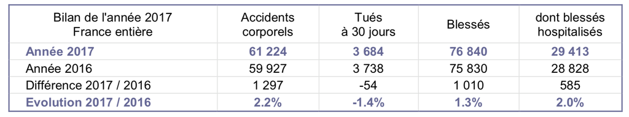

```python
from IPython.display import Image
Image(filename='Img1.png')
```

Nous pouvons donc étudier ce phénomene suivant plusieurs aspects tel que les victimes (Tuées ou bléssées) selon le genre, l'age, le lieu, les types des véhicules..  
Pour ainsi, dégager quelques indicateurs clés à étudier.

# III - Compréhension des données

## 1 - Données supplémentaires

- Données des communes :
- Les jours fériès en France :

## 2 - Préparation des données

```python
import pandas as pd
from tqdm import tqdm
from datetime import timedelta
import numpy as np
import math
import matplotlib.pyplot as plt
import tensorflow as tf
from sklearn.preprocessing import MinMaxScaler
import warnings
warnings.filterwarnings("ignore")
%matplotlib inline
```

```python
lieux = pd.read_csv("final_lieux.csv")
usagers = pd.read_csv("final_usagers.csv")
vehicules = pd.read_csv("final_vehicules.csv")
caracteristiques = pd.read_csv("final_caracteristiques.csv")

data = caracteristiques
data = data.merge(usagers, left_on='Num_Acc', right_on='Num_Acc', how='inner')
data = data.merge(vehicules, left_on='Num_Acc', right_on='Num_Acc', how='inner')
data = data.merge(lieux, left_on='Num_Acc', right_on='Num_Acc', how='inner')

data.drop(["Unnamed: 0_x","Unnamed: 0_y"],axis = 1,inplace = True)
```

```python
data.shape
```

```
(3814368, 52)
```

Nous possédons à ce stade, un dataframe qui contient 3.814.368 lignes et 52 colonnes. Chaque ligne décrit une personne impliquée dans l'accident ayant l'identifiant **Num_Acc**.

Nous importons maintenant les deux fichiers contenant des données supplémentaires :

```python
feries = pd.read_csv("jours_feries_seuls.csv")
codes_insee = pd.read_csv("correspondance-code-insee-code-postal.csv",sep=";")
```

- Ensuite, nous allons créer une nouvelle colonne qui contiendra la date complète sous le format Y-m-d. Cette colonne nous permettera de trouver les accidents survenus pendant des jours fériès ou aussi pendant les weekends.

```python
Full_Date = []
if(max(data.an) < 2000):
    data.an = data.an + 2000
for i in tqdm(range(0,len(data))):
    Full_Date.append(pd.datetime((data.iloc[i,1]),data.iloc[i,2],data.iloc[i,3]))
data["Full_Date"] = Full_Date
data.head(5)
```

|  | Num_Acc | an | mois | jour | hrmn | lum | agg | int | atm | col | ... | vosp | prof | plan | lartpc | larrout | surf | infra | situ | env1 | Full_Date |
| --- | --- | --- | --- | --- | --- | --- | --- | --- | --- | --- | --- | --- | --- | --- | --- | --- | --- | --- | --- | --- | --- |
| 0 | 201700000001 | 2017 | 1 | 11 | 1820 | 5 | 2 | 1 | 1.0 | 1.0 | ... | 2.0 | 1.0 | 1.0 | 0.0 | 70.0 | 1.0 | 0.0 | 1.0 | 99.0 | 2017-01-11 |
| 1 | 201700000001 | 2017 | 1 | 11 | 1820 | 5 | 2 | 1 | 1.0 | 1.0 | ... | 2.0 | 1.0 | 1.0 | 0.0 | 70.0 | 1.0 | 0.0 | 1.0 | 99.0 | 2017-01-11 |
| 2 | 201700000001 | 2017 | 1 | 11 | 1820 | 5 | 2 | 1 | 1.0 | 1.0 | ... | 2.0 | 1.0 | 1.0 | 0.0 | 70.0 | 1.0 | 0.0 | 1.0 | 99.0 | 2017-01-11 |
| 3 | 201700000001 | 2017 | 1 | 11 | 1820 | 5 | 2 | 1 | 1.0 | 1.0 | ... | 2.0 | 1.0 | 1.0 | 0.0 | 70.0 | 1.0 | 0.0 | 1.0 | 99.0 | 2017-01-11 |
| 4 | 201700000001 | 2017 | 1 | 11 | 1820 | 5 | 2 | 1 | 1.0 | 1.0 | ... | 2.0 | 1.0 | 1.0 | 0.0 | 70.0 | 1.0 | 0.0 | 1.0 | 99.0 | 2017-01-11 |

5 rows × 53 columns

- Marquage des jours fériès :  
  Puisque nous travaillons sur les accidents survenus entre 2005 et 2017, nous pouvons supprimer les jours fériès ayant l'année qui précéde ou dépasse ces deux nombres, dans le but de minimiser le temps de traitement.

```python
feries = feries.drop(feries[(feries.date < "2005") | (feries.date > "2017")].index)
data["Holiday"] = "Non"
for i in tqdm(range(0,len(feries))):
    data.loc[data.Full_Date == feries.iloc[i,0],"Holiday"] = feries.iloc[i,2]
```

```python
feries.date=feries.date.apply(lambda x: pd.to_datetime(x))
dayslist=[]
for i in tqdm(range(0, len(feries))):
    dayslist.append(feries.iloc[i,0]-timedelta(days=1))
    dayslist.append(feries.iloc[i,0])
    dayslist.append(feries.iloc[i,0]+timedelta(days=1))

data["IS_Holiday"]=data["Full_Date"].apply(lambda x: "Yes" if x in dayslist else "No")
```

**Période de l'accident dans la journée** : Au lieu d'utiliser la colonne *hrmn*, nous allons déduire une nouvelle colonne catégorique *Periode* qui contiendra les modalités suivantes :

- Aube
- Jour
- Coucher de soleil
- Nuit

```python
def periode_accident(x):
    if x< 600:
        return "Aube"
    elif x<1600:
        return "Jour"
    elif x<1900:
        return "Coucher de soleil"
    else:
        return "Nuit"
data["Periode"]=data["hrmn"].apply(lambda x: periode_accident(x))
```

**Ajout de la colonne *Weekend/Weekday*** : On s'intéressera par la suite par la comparaison de nombre des accidents survenu au cours de la semaine et au cours du weekend.

```python
weekend=[]
for i in tqdm(range(0,len(data))):
    date=data.iloc[i,52]
    if int(date.weekday()) in [5,6]:
        weekend.append("weekend")
    else:
        weekend.append("workday")
data["Weekend"]=weekend
```

### A) Changement des noms des colonnes

```python
colnames = ["Num_Accident","Annee","Mois","Jour","Heure_Minutes","Lumiere","Agglomeration",
            "Intersection","Atmosphere","Type_Collision","Commune","Adresse_Postale","GPS",
            "Latitude","Longitude","Departement","Place","Categorie_Usager","Gravite",
            "Sexe_Usager","Trajet","Securite","Localisation_Pieton","Action_Pieton","Etat_Pieton",
            "Annee_Naissance","Numero_Vehicule_X","Sens_Circulation","Categorie_Vehicule",
            "Nb_Occupents_Transport_Commun","Obstacle_Fixe_Heurte","Obstacle_Mobile_Heurte",
            "Pt_Choc_initiale","Manoeuvre","Numero_Vehicule_Y","Categorie_Route","Voie",
            "Indice_Numerique_Route","Lettre_indice_Alphanum_Route","Regime_Circulation",
            "Nb_Voies_Circulation","Num_PR_Rattachement","Distance_Au_PR","Voie_Reservee",
            "Declivite_Route","Trace_En_Plan","Largeur_Terre_Plein_Centrale","Largeur_Chausse_Affectee",
            "Etat_Surface","Infrastructure","Situation_Accident","Proximite_Ecole","Full_Date",
            "Holiday","IS_Holiday","Periode","Weekend"]
data.columns = colnames
```

### B) Changement des modalités des variables catégoriques

```python
data = data.replace({
'Lumiere':{
1 : 'Plein jour',
2 : 'Crépuscule ou aube' ,
3 : 'Nuit sans éclairage public',
4 : 'Nuit avec éclairage public non allumé' ,
5 : 'Nuit avec éclairage public allumé' },
'Agglomeration':{
1:'Hors agglomération' ,
2 :'En agglomération',

},
'Intersection': {1 : 'Hors intersection ',
2 : 'Intersection en X,',
3 : 'Intersection en T' ,
4 : 'Intersection en Y' ,
5 :'Intersection à plus de 4 branches' ,
6 : 'Giratoire',
7 :'Place' ,
8 :'Passage à niveau' ,
9 : 'Autre intersection' },
'Atmosphere':{
1 : 'Normale',
2 : 'Pluie légère',
3 : 'Pluie forte',
4 : 'Neige - grêle',
5 : 'Brouillard - fumée',
6 : 'Vent fort - tempête',
7 : 'Temps éblouissant',
8 : 'Temps couvert',
9 : 'Autre'
},
'Type_Collision':{
1 : 'Deux véhicules - frontale',
2 : 'Deux véhicules – par l’arrière',
3 : 'Deux véhicules – par le coté',
4 : 'Trois véhicules et plus – en chaîne',
5 : 'Trois véhicules et plus  - collisions multiples',
6 : 'Autre collision',
7 : 'Sans collision'
},
'GPS':{'M' : 'Métropole',
'A' : 'Antilles (Martinique ou Guadeloupe)',
'G' : 'Guyane',
'R' : 'Réunion',
'Y' : 'Mayotte' },
'Categorie_Route':{
1 : 'Autoroute',
2 : 'Route Nationale',
3 : 'Route Départementale',
4 : 'Voie Communale',
5 : 'Hors réseau public',
6 : 'Parc de stationnement ouvert à la circulation publique',
9 : 'autre'
},
'Regime_Circulation':{
1 : 'A sens unique',
2 : 'Bidirectionnelle',
3 : 'A chaussées séparées',
4 : 'Avec voies d’affectation variable'
},
'Voie_Reservee':{
1 : 'Piste cyclable',
2 : 'Banque cyclable',
3 : 'Voie réservée'
},
'Etat_Surface':{
1 : 'normale',
2 : 'mouillée' ,
3 : 'flaques',
4 : 'inondée' ,
5 : 'enneigée',
6 : 'boue',
7 : 'verglacée',
8 : 'corps gras : huile',
9 : 'autre'
},
'Infrastructure':{
1 : 'Souterrain : tunnel',
2 : 'Pont : autopont',
3 : 'Bretelle d’échangeur ou de raccordement',
4 : 'Voie ferrée',
5 : 'Carrefour aménagé' ,
6 : 'Zone piétonne' ,
7 : 'Zone de péage'
} ,
'Situation_Accident':{
1 : 'Sur chaussée',
2 : 'Sur bande d’arrêt d’urgence ',
3 : 'Sur accotement',
4 : 'Sur trottoir',
5 : 'Sur piste cyclabl'
},

'Categorie_Vehicule':{
1 : 'Bicyclette',
2 : 'Cyclomoteur <50cm3',
3 : 'Voiturette (Quadricycle à moteur carrossé) (anciennement "voiturette outricycle à moteur") ',
4 : 'Référence plus utilisée depuis 2006 (scooter immatriculé)',
5 : 'Référence plus utilisée depuis 2006 (motocyclette)',
6 : 'Référence plus utilisée depuis 2006 (side:car) ',
7 : 'VL seul' ,
8 : 'Catégorie plus utilisée (VL + caravane)' ,
9 : 'Catégorie plus utilisée (VL + remorque)' ,
10 : 'VU seul 1,5T <: PTAC <: 3,5T avec ou sans remorque (anciennement VU seul 1,5T <: PTAC <: 3,5T)' ,
11 :'Référence plus utilisée depuis 2006 (VU (10) + caravane)',
12 :'Référence plus utilisée depuis 2006 (VU (10) + remorque)',
13 : 'PL seul 3,5T <PTCA <: 7,5T ',
14 : 'PL seul > 7,5T',
15 : 'PL > 3,5T + remorque',
16 : 'Tracteur routier seul' ,
17 : 'Tracteur routier + semi:remorque' ,
18 :  'transport en commun',
19 : 'tramway',
20 : 'Engin spécial',
21 : 'Tracteur agricole',
30 : 'Scooter < 50 cm3',
31 : 'Motocyclette > 50 cm3 et <: 125 cm3',
32 : 'Scooter  > 50 cm3 et <: 125 cm3',
33 : 'Motocyclette > 125 cm3',
34 : 'Scooter  > 125 cm3',
35 : 'Quad léger  <: 50 cm3 ',

36 : 'Quad lourd > 50 cm3',
37 : 'Autobus',
38 : 'Autocar' ,
39 : 'Train',
40 : 'Tramway',
99 : 'Autre véhicule'
},

'Obstacle_Fixe_Heurte':{
1 : 'Véhicule en stationnement',
2 : 'Arbre ',
3 : 'Glissière métallique',
4 : 'Glissière béton',
5 : 'Autre glissière ',
6 : 'Bâtiment, mur, pile de pont',
7 : 'Support de signalisation verticale ou poste d’appel d’urgence',
8 : 'Poteau ',
9 : 'Mobilier urbain',
10 : 'Parapet',
11 : 'Ilot, refuge, borne haute' ,
12 : 'Bordure de trottoir ',
13 : 'Fossé, talus, paroi rocheuse',
14 : 'Autre obstacle fixe sur chaussée',
15 : 'Autre obstacle fixe sur trottoir ou accotement',
16 : 'Sortie de chaussée sans obstacle',
},
'Obstacle_Mobile_Heurte':{
1 : 'Piéton',
2 : 'Véhicule',
4 : 'Véhicule sur rail',
5 : 'Animal domestique',
6 : 'Animal sauvage',
9 : 'Autre'
},

'Pt_Choc_initiale':{
1 :  'Avant',
2 : 'Avant droit',
3 : 'Avant gauche',
4 : 'Arrière' ,
5 : 'Arrière droit ',
6 : 'Arrière gauche',
7 : 'Côté droit ',
8 : 'Côté gauche ',
9 : 'Chocs multiples (tonneaux)',
},

'Manoeuvre':{
1 : 'Sans changement de direction',
2 : 'Même sens, même file',
3 : 'Entre 2 files',
4 : 'En marche arrière ',
5 : 'A contresens',
6 : 'En franchissant le terre:plein central',
7 : 'Dans le couloir bus, dans le même sens',
8 : 'Dans le couloir bus, dans le sens inverse',
9 : 'En s’insérant' ,
10 : 'En faisant demi:tour sur la chaussée ',

11   : 'Changeant de file A gauche',
12   : 'Changeant de file A droite ',

13   : 'Déporté A gauche',
14   : 'Déporté A droite',
15   : 'Tournant A gauche',
16   : 'Tournant  A droite ',

17   : 'Dépassant A gauche',
18   : 'Dépassant A droite',
19   : 'Traversant la chaussée',
20   : 'Manœuvre de stationnement',
21   : 'Manœuvre d’évitement',
22   : 'Ouverture de porte',
23   : 'Arrêté (hors stationnement)',
24   : 'En stationnement (avec occupants) ',
},

'Localisation_Pieton' :{
0 : 'non renseigné ou sans objet',
1 : 'A + 50 m du passage piéton',
2 : 'A - 50 m du passage piéton',

3 : 'Sans signalisation lumineuse',
4 : 'Avec signalisation lumineuse',

5 : 'Sur trottoir',
6 : 'Sur accotement',
7 : 'Sur refuge ou BAU' ,
8 : 'Sur contre allée'
},
'Action_Pieton':{
0 : 'non renseigné ou sans objet',
1 : 'Sens véhicule heurtant',
2 : 'Sens inverse du véhicule ',
3 : 'Traversant',
4 : 'Masqué',
5 : 'Jouant : courant',
6 : 'Avec animal',
9 : 'Autre'
},

'Etat_Pieton':{
0 : 'non renseigné ou sans objet',
1 : 'Seul',
2 : 'Accompagné',
3 : 'En groupe'
},

'Categorie_Usager':{
1 : 'Conducteur',
2 : 'Passager',
3 : 'Piéton',
4 : 'Piéton en roller ou en trottinette'
},

'Gravite':{
1 : 'Indemne',
2 : 'Tué',
3 : 'Blessé hospitalisé ',
4 : 'Blessé léger'
},

'Sexe_Usager':{
1 : 'Masculin',
2 : 'Féminin',
},


'Trajet':{
1 : 'Domicile – travail',
2 : 'Domicile – école',
3 : 'Courses – achats' ,
4 : 'Utilisation professionnelle',
5 : 'Promenade – loisirs',
9 : 'Autre'
}})
```

### C) Ajout des données des communes

```python
NO_ = [201,202,971,972,973,974,975,976]
data.Departement = data.Departement.apply(lambda x: int(x/10) if x not in NO_ else x)
```

```python
data = data.loc[np.isnan(data["Commune"]) == False,:]
data.Commune = data.Commune.astype("int")
data_backup = data.copy()
data_backup.Departement = data_backup.Departement.astype("str")
codes_insee.rename(index = str,columns = {"Commune" : "Nom_Commune","Code INSEE" : "Code_INSEE","Code Département" : "Code_Departement"},inplace=True)
data_backup = pd.merge(data_backup,codes_insee[["Nom_Commune","Population","Code_INSEE","Code_Departement","Code Commune"]],right_on = ["Code_Departement","Code Commune"], left_on= ["Departement","Commune"],how = "left")
data_backup.drop(["Code_Departement","Code Commune"],axis = 1,inplace = True)
data = data_backup.copy()
```

```python
data.Population = data.Population*1000
```

### D) Pourcentage des données manquantes

```python
def missing_data(data):
    total = round(data.isnull().sum().sort_values(ascending = False),2)
    percent = round((data.isnull().sum()/data.isnull().count()*100).sort_values(ascending = False),2)
    return pd.concat([total, percent.astype("str")+" %"], axis=1, keys=['Total NaN Values', 'Percentage of NaN Values'])

missing_data(data)
```

|  | Total NaN Values | Percentage of NaN Values |
| --- | --- | --- |
| Lettre_indice_Alphanum_Route | 3641799 | 95.48 % |
| Indice_Numerique_Route | 2388482 | 62.62 % |
| Longitude | 2006892 | 52.61 % |
| Latitude | 2006872 | 52.61 % |
| GPS | 1973074 | 51.73 % |
| Distance_Au_PR | 1775939 | 46.56 % |
| Num_PR_Rattachement | 1769657 | 46.39 % |
| Adresse_Postale | 667552 | 17.5 % |
| Population | 581345 | 15.24 % |
| Code_INSEE | 581345 | 15.24 % |
| Nom_Commune | 581345 | 15.24 % |
| Voie | 255995 | 6.71 % |
| Place | 116299 | 3.05 % |
| Securite | 55705 | 1.46 % |
| Largeur_Terre_Plein_Centrale | 49478 | 1.3 % |
| Largeur_Chausse_Affectee | 43494 | 1.14 % |
| Proximite_Ecole | 22399 | 0.59 % |
| Infrastructure | 22161 | 0.58 % |
| Situation_Accident | 20077 | 0.53 % |
| Voie_Reservee | 9678 | 0.25 % |
| Nb_Voies_Circulation | 9643 | 0.25 % |
| Trace_En_Plan | 8385 | 0.22 % |
| Declivite_Route | 6300 | 0.17 % |
| Etat_Surface | 6217 | 0.16 % |
| Action_Pieton | 5394 | 0.14 % |
| Etat_Pieton | 5254 | 0.14 % |
| Localisation_Pieton | 5171 | 0.14 % |
| Regime_Circulation | 4810 | 0.13 % |
| Annee_Naissance | 4309 | 0.11 % |
| Obstacle_Fixe_Heurte | 3766 | 0.1 % |
| Manoeuvre | 2330 | 0.06 % |
| Obstacle_Mobile_Heurte | 1779 | 0.05 % |
| Pt_Choc_initiale | 1174 | 0.03 % |
| Trajet | 851 | 0.02 % |
| Sens_Circulation | 303 | 0.01 % |
| Atmosphere | 247 | 0.01 % |
| Type_Collision | 73 | 0.0 % |
| Categorie_Route | 2 | 0.0 % |
| Intersection | 0 | 0.0 % |
| Mois | 0 | 0.0 % |
| Agglomeration | 0 | 0.0 % |
| Jour | 0 | 0.0 % |
| Commune | 0 | 0.0 % |
| Annee | 0 | 0.0 % |
| Heure_Minutes | 0 | 0.0 % |
| Lumiere | 0 | 0.0 % |
| Nb_Occupents_Transport_Commun | 0 | 0.0 % |
| Departement | 0 | 0.0 % |
| Categorie_Usager | 0 | 0.0 % |
| Gravite | 0 | 0.0 % |
| Sexe_Usager | 0 | 0.0 % |
| Numero_Vehicule_X | 0 | 0.0 % |
| Categorie_Vehicule | 0 | 0.0 % |
| Numero_Vehicule_Y | 0 | 0.0 % |
| Full_Date | 0 | 0.0 % |
| Holiday | 0 | 0.0 % |
| IS_Holiday | 0 | 0.0 % |
| Periode | 0 | 0.0 % |
| Weekend | 0 | 0.0 % |
| Num_Accident | 0 | 0.0 % |

## 3 - Data Visualization

On commence par l'importation des bibliothèques graphiques :

```python
from plotly.offline import plot,init_notebook_mode, iplot
import plotly.graph_objs as go
import plotly.plotly as py
import seaborn as sns
from plotly import tools
init_notebook_mode(connected=True)
```

Cette fonction permet de créer un tableau d'effectifs par modalité pour une colonne précise.

```python
def create_stack_bar_data(col, df):
    aggregated = df[col].value_counts().sort_index()
    x_values = aggregated.index.tolist()
    y_values = aggregated.values.tolist()
    return x_values, y_values
```

### L'évolution des nombres des accidents à travers les années

Puisque on étudie l'évolution de nombre des **Accidents**, on s'intéresse à créer un dataframe dans lequel chaque ligne correspond à un accident.

```python
data_accidents = data.drop_duplicates(["Num_Accident"]).copy()
```

```python
x1, y1 = create_stack_bar_data('Annee', data_accidents)
color1 = ['092a35']*9
color2 = ['a2738c']*3
color1 = ["#"+c for c in color1]
color2 = ["#"+c for c in color2]
color1.extend(color2)
trace1 = go.Bar(x=x1, y=y1, opacity=0.75, name="Nombre par année", marker = dict(color = color1))
layout = dict(height=400, title='Évolution de nombre des accidents par année en France', legend=dict(orientation="h"),
              xaxis = dict(title = 'Année'), yaxis = dict(title = 'Nombre des accidents'))
fig = go.Figure(data=[trace1], layout=layout)
iplot(fig)
```

[interactive chart not shown]

### Répartition des accidents par mois

```python
import calendar
x2, y2 = create_stack_bar_data('Mois', data_accidents)
c = calendar.LocaleTextCalendar(locale = "fr_FR")
xn = [c.formatmonthname(themonth = int(x),withyear = False,width = 0,theyear = 2017) for x in (x2)]
vn = y2

trace1 = go.Bar(x=xn, y=vn, opacity=0.75, name="Mois", marker=dict(color = "#404b69"))
layout = dict(height=400, title='Évolution de nombre des accidents par mois en France', legend=dict(orientation="h"));

fig1 = go.Figure(data=[trace1], layout=layout)
iplot(fig1)
```

[interactive chart not shown]

### Quel est le jour le plus sûr de mois

```python
x3, y3 = create_stack_bar_data('Jour', data_accidents)
trace1 = go.Bar(x=x3, y=y3, opacity=0.75, name="Jour du mois", marker=dict(color = "#305c69"))
layout = dict(height=400, title='Évolution de nombre des accidents par jour en France', legend=dict(orientation="h") );

fig2 = go.Figure(data=[trace1], layout=layout)
iplot(fig2)
```

[interactive chart not shown]

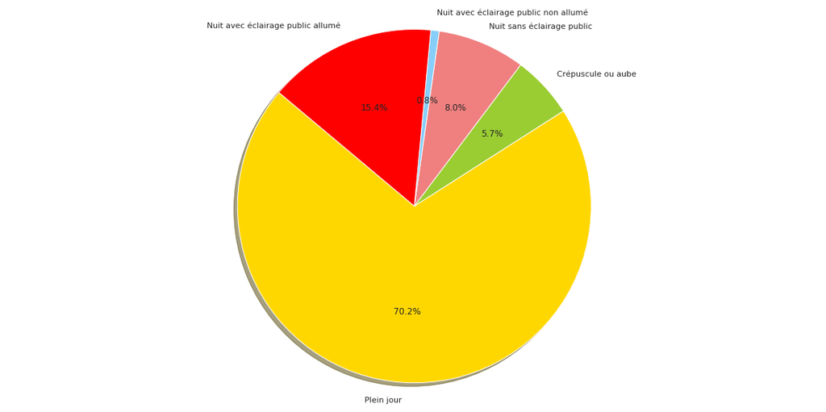

```python
c1=data.loc[data['Lumiere'] =='Plein jour' ]
c2=data.loc[data['Lumiere'] =='Crépuscule ou aube' ]
c3=data.loc[data['Lumiere'] =='Nuit sans éclairage public' ]
c4=data.loc[data['Lumiere'] =='Nuit avec éclairage public non allumé' ]
c5=data.loc[data['Lumiere'] =='Nuit avec éclairage public allumé' ]
labels = 'Plein jour', 'Crépuscule ou aube', 'Nuit sans éclairage public', 'Nuit avec éclairage public non allumé','Nuit avec éclairage public allumé'
sizes = [c1['Lumiere'].count(),c2['Lumiere'].count(),c3['Lumiere'].count(),c4['Lumiere'].count(),c5['Lumiere'].count()]
colors = ['gold', 'yellowgreen', 'lightcoral', 'lightskyblue','red']
explode = (0, 0, 0, 0,0)  # explode 1st slice
fig = plt.figure(figsize=(20,10))
# Plot
plt.pie(sizes, explode=explode, labels=labels, colors=colors,
        autopct='%1.1f%%', shadow=True, startangle=140)

plt.axis('equal')
plt.show()
```

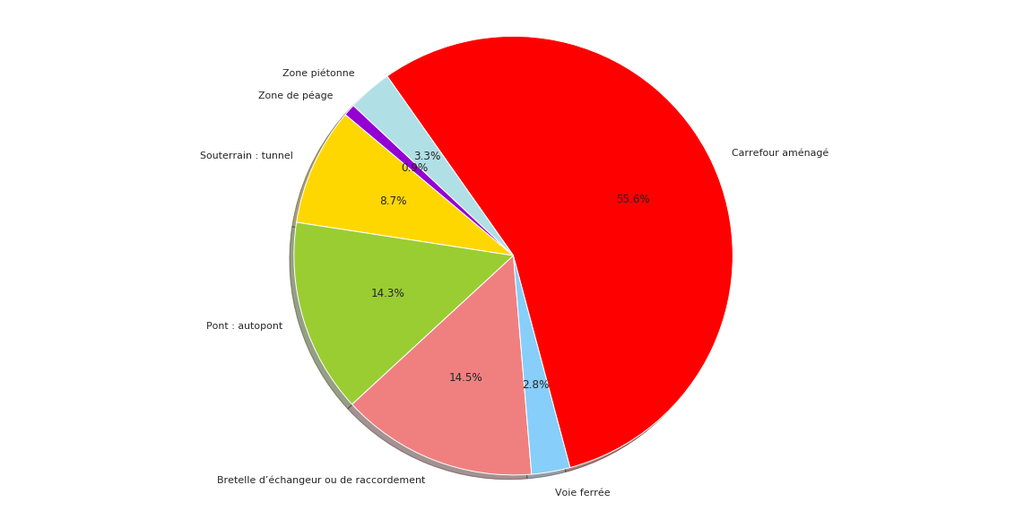

```python
infra={
1 : 'Souterrain : tunnel',
2 : 'Pont : autopont',
3 : 'Bretelle d’échangeur ou de raccordement',
4 : 'Voie ferrée',
5 : 'Carrefour aménagé' ,
6 : 'Zone piétonne' ,
7 : 'Zone de péage'
}
c1=data.loc[data['Infrastructure'] ==infra[1] ]
c2=data.loc[data['Infrastructure'] ==infra[2] ]
c3=data.loc[data['Infrastructure'] ==infra[3] ]
c4=data.loc[data['Infrastructure'] ==infra[4] ]
c5=data.loc[data['Infrastructure'] ==infra[5] ]
c6=data.loc[data['Infrastructure'] ==infra[6] ]
c7=data.loc[data['Infrastructure'] ==infra[7] ]
labels = 'Souterrain : tunnel', 'Pont : autopont', 'Bretelle d’échangeur ou de raccordement', 'Voie ferrée', 'Carrefour aménagé' ,'Zone piétonne' ,'Zone de péage'
sizes = [c1['Infrastructure'].count(),c2['Infrastructure'].count(),c3['Infrastructure'].count(),c4['Infrastructure'].count(),c5['Infrastructure'].count(),c6['Infrastructure'].count(),c7['Infrastructure'].count()]
colors = ['gold', 'yellowgreen', 'lightcoral', 'lightskyblue','red','Powderblue','Darkviolet']
explode = (0, 0, 0, 0,0,0,0)  # explode 1st slice
fig = plt.figure(figsize=(20,10))
# Plot
plt.pie(sizes, explode=explode, labels=labels, colors=colors,
        autopct='%1.1f%%', shadow=True, startangle=140)

plt.axis('equal')
plt.show()
```

### Comparaison de Weekends/Workdays

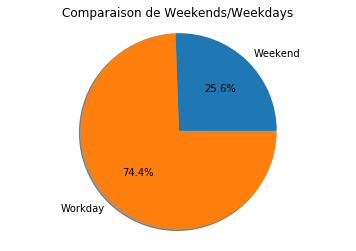

```python
labels = ['Weekend', 'Workday']
sizes = [data_accidents.loc[data_accidents["Weekend"] == "weekend",:].shape[0],
         data_accidents.loc[data_accidents["Weekend"] == "workday",:].shape[0],
        ]
fig4, ax1 = plt.subplots()
ax1.pie(sizes, labels=labels, autopct='%1.1f%%', shadow=True)
ax1.axis('equal')
plt.title('Comparaison de Weekends/Weekdays')
plt.show()
```

### Répartition de nombre des accidents par heure

```python
tempas = data.drop_duplicates(["Num_Accident"]).loc[:, ['Num_Accident' , 'Heure_Minutes']]
tempas['hour'] = tempas['Heure_Minutes'].apply(lambda x:str(x).zfill(4)[:2])


occs = tempas.drop('Heure_Minutes' , axis = 1).groupby('hour' , as_index = False).agg({'Num_Accident' : 'count'})



trace1 = go.Area(
    r=list(occs.Num_Accident),
    t=list(occs.hour),
    name='Nombre des accidents',
    marker=dict(
        color='rgb(106,81,163)'
    )
)

data2 = [trace1]

layout = go.Layout(
    title='Répartition des accidents par heure',
    autosize = False,
    width = 1000,
    height = 400,
    orientation=-90

)
fig = go.Figure(data=data2, layout=layout)
iplot(fig)
```

[interactive chart not shown]

### Répartition de nombre des accidents par jour de semaine

```
(0, 160363)
```

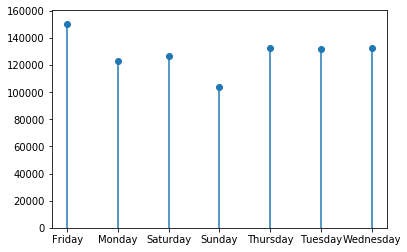

```python
fig5, ax2 = plt.subplots()
data_per_day = data.drop_duplicates(["Num_Accident"]).copy()
data_per_day["Jour_De_Semaine"] = [calendar.day_name[x.weekday()] for x in data_per_day["Full_Date"]]
data_per_day.drop(data_per_day.columns.difference(["Jour_De_Semaine","Num_Accident"]),axis = 1,inplace = True)
data_per_day = data_per_day.groupby("Jour_De_Semaine",as_index = False).agg("count")
ax2.stem(data_per_day.Jour_De_Semaine, data_per_day.Num_Accident, basefmt=' ')
ax2.set_ylim(0, max(data_per_day.Num_Accident)+10000)
```

### Relation entre la gravité de la condition de chaque individu et la présence de l'équipement de sécurité

```python
safety = data[['Securite', 'Gravite']]
safety = safety.dropna()
safety.Gravite = safety.Gravite.replace(['Indemne','Tué','Blessé hospitalisé ','Blessé léger'],[1,2,3,4])
safety['Equipment'] = (safety.Securite/10).astype(int)
safety.Securite = (safety.Securite - safety.Equipment*10).astype(int)
keydict = {1:'Indemne', 2:'Tué', 3: 'Blessé hospitalisé ', 4: 'Blessé léger'}
traces = []
for key, grp in safety.groupby(safety.Gravite):
    if (key != 0):
        count = safety.Securite.count()
        aggregated = (grp.Securite.value_counts()).sort_index()
        x_values = aggregated.index.tolist()
        y_values = (aggregated.values/safety.Securite.value_counts().sort_index().values*100).tolist()
        x1,y1 = x_values[1:], y_values[1:]
        x1 = ['Equipement Présent','Equipement Absent', 'Non Determiné']


        globalcolors = ['#092a35', '#a2738c', '#645c84', '#427996', '#658525', '#404b69', '#0f4471', '#0f4471', '#0f4471', '#0f4471']

        trace4 = go.Bar(x=x1, y=y1, opacity=0.75, name = keydict[key],
                        marker = dict(color = globalcolors[key-2]))
        layout4 = dict(height=400, title="Relation entre la gravité de la condition de chaque individu et la présence de l'équipement de sécurité",
                      legend=dict(orientation="h"), barmode = 'stack', yaxis = dict(title = 'Pourcentage'),
                      xaxis = dict(title = 'Équipement de sécurité'));
        traces.append(trace4)
fig6 = go.Figure(data= traces, layout=layout4)
iplot(fig6)
```

[interactive chart not shown]

On remarque que le nombre des personnes blessés légerement, hospitalisés et tués augmente d'une façon remarquable à l'absence de l'équipement de sécurité (Ceinture, Casque ...)

# IV - Modélisation

## Segmentation des communes par indicateurs

```python
import numpy as np
import functools
lieux=pd.read_csv("Data/lieux_2016.csv")
vehicules=pd.read_csv("Data/vehicules_2016.csv")
usagers=pd.read_csv("Data/usagers_2016.csv")
caracteristiques=pd.read_csv("Data/caracteristiques_2016.csv",encoding='latin-1')
df4 = caracteristiques
df4 = df4.merge(usagers, left_on='Num_Acc', right_on='Num_Acc', how='inner')
df4 = df4.merge(vehicules, left_on='Num_Acc', right_on='Num_Acc', how='inner')
df4 = df4.merge(lieux, left_on='Num_Acc', right_on='Num_Acc', how='inner')
```

```python
colnames = ["Num_Accident","Annee","Mois","Jour","Heure_Minutes","Lumiere","Agglomeration",
            "Intersection","Atmosphere","Type_Collision","Commune","Adresse_Postale","GPS",
            "Latitude","Longitude","Departement","Place","Categorie_Usager","Gravite",
            "Sexe_Usager","Trajet","Securite","Localisation_Pieton","Action_Pieton","Etat_Pieton",
            "Annee_Naissance","Numero_Vehicule_X","Sens_Circulation","Categorie_Vehicule",
            "Nb_Occupents_Transport_Commun","Obstacle_Fixe_Heurte","Obstacle_Mobile_Heurte",
            "Pt_Choc_initiale","Manoeuvre","Numero_Vehicule_Y","Categorie_Route","Voie",
            "Indice_Numerique_Route","Lettre_indice_Alphanum_Route","Regime_Circulation",
            "Nb_Voies_Circulation","Num_PR_Rattachement","Distance_Au_PR","Voie_Reservee",
            "Declivite_Route","Trace_En_Plan","Largeur_Terre_Plein_Centrale","Largeur_Chausse_Affectee",
            "Etat_Surface","Infrastructure","Situation_Accident","Proximite_Ecole"]
df4.columns = colnames
```

```python
df4['Gravite'].head()
len(df4.Num_Accident.unique())
```

```
59432
```

```python
df4.groupby('Num_Accident')
listt=[]
for i,j in df4.iterrows():
    if (((j['Gravite']==2) or j['Gravite']==3 )):
         listt.append(1)

    else:
        listt.append(0)
df4['ind1']=listt
```

```python
df4=df4.replace({
'Gravite':{
1 : 'Indemne',
2 : 'Tué',
3 : 'Blessé hospitalisé ',
4 : 'Blessé léger'
},
})
df4=oneHotEncode(df4,['Gravite'])
```

```python
ls=pd.DataFrame(df4.groupby('Num_Accident').size())
ls=ls.reset_index()
ls=ls.rename(index=str, columns={0: "Number"})
listeE=df4.groupby('Num_Accident').agg({'ind1':np.sum})
```

```python
listeind=df4.groupby('Commune',as_index = False).agg({'Gravite_Tué':np.sum})
df6=pd.DataFrame(df4.drop_duplicates(["Num_Accident"]).groupby('Commune').size())
```

```python
df6=df6.rename(index=str, columns={0: "Number"})
df6.head()
```

| Commune | Number |
| --- | --- |
| 1 | 369 |
| 2 | 189 |
| 3 | 152 |
| 4 | 451 |
| 5 | 459 |

```python
km = df6.loc[:,'Number'].as_matrix()
bm = listeind.loc[:,'Gravite_Tué'].as_matrix()
lo = (bm/km)
```

```python
ko = ls.loc[:,'Number'].as_matrix()
bi = listeE.loc[:,'ind1'].as_matrix()
zw = (bi/ko)
```

```python
df5=df4.drop_duplicates(["Num_Accident"])
```

```python
df5['Indicateur1']=zw
```

```python
listeM=df5.groupby(['Commune'],as_index = False).agg({'Indicateur1':np.mean})
```

```python
listeM['Indicateur2']=lo
listeM.head()
```

|  | Commune | Indicateur1 | Indicateur2 |
| --- | --- | --- | --- |
| 0 | 1 | 0.266260 | 0.102981 |
| 1 | 2 | 0.225309 | 0.111111 |
| 2 | 3 | 0.334336 | 0.092105 |
| 3 | 4 | 0.240158 | 0.133038 |
| 4 | 5 | 0.199785 | 0.021786 |

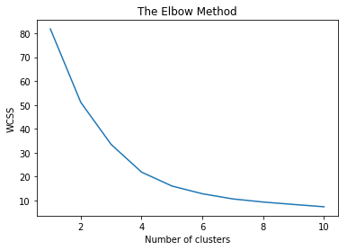

```python
from sklearn.cluster import KMeans
wcss = []
X = listeM.loc[:, ['Indicateur1','Indicateur2']].values
for i in range(1, 11):
    kmeans = KMeans(n_clusters = i, init = 'k-means++', random_state = 42)
    kmeans.fit(X)
    wcss.append(kmeans.inertia_)
plt.plot(range(1, 11), wcss)
plt.title('The Elbow Method')
plt.xlabel('Number of clusters')
plt.ylabel('WCSS')
plt.show()
```

```python
kmeans = KMeans(n_clusters = 4, init = 'k-means++', random_state = 42)
y_kmeans = kmeans.fit_predict(X)
```

```python
listeM['Cluster']=y_kmeans
listeM.groupby(['Cluster'])[['Indicateur1','Indicateur2']].describe()
```

| Cluster | Indicateur1 count | Indicateur1 mean | Indicateur1 std | Indicateur1 min | Indicateur1 25% | Indicateur1 50% | Indicateur1 75% | Indicateur1 max | Indicateur2 count | Indicateur2 mean | Indicateur2 std | Indicateur2 min | Indicateur2 25% | Indicateur2 50% | Indicateur2 75% | Indicateur2 max |
| --- | --- | --- | --- | --- | --- | --- | --- | --- | --- | --- | --- | --- | --- | --- | --- | --- |
| 0 | 101.0 | 0.534536 | 0.140680 | 0.266667 | 0.450000 | 0.505556 | 0.583333 | 1.000000 | 101.0 | 0.525881 | 0.207121 | 0.322581 | 0.368421 | 0.428571 | 0.666667 | 1.000000 |
| 1 | 410.0 | 0.261955 | 0.095867 | 0.000000 | 0.203212 | 0.277309 | 0.334510 | 0.407738 | 410.0 | 0.080170 | 0.071322 | 0.000000 | 0.023335 | 0.071429 | 0.117556 | 0.333333 |
| 2 | 297.0 | 0.548340 | 0.128000 | 0.392437 | 0.466667 | 0.509259 | 0.575000 | 1.000000 | 297.0 | 0.116664 | 0.107797 | 0.000000 | 0.000000 | 0.115385 | 0.214286 | 0.321429 |
| 3 | 6.0 | 0.529040 | 0.229781 | 0.218750 | 0.404115 | 0.500000 | 0.687500 | 0.833333 | 6.0 | 2.281609 | 0.487741 | 2.000000 | 2.000000 | 2.000000 | 2.375000 | 3.189655 |

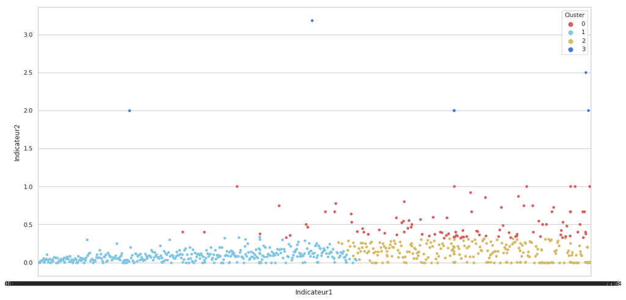

```python
import seaborn as sns
sns.set(style="whitegrid", palette="muted")
plt.figure(figsize = (18,9))

# Load the example iris dataset

# "Melt" the dataset to "long-form" or "tidy" representation

# Draw a categorical scatterplot to show each observation
sns.swarmplot(x="Indicateur1", y="Indicateur2", hue="Cluster",
              palette=["r", "c", "y",'b'], data=listeM)
```

## Indicateur 1 : Nombre des impliqués dans des accidents lors des événements

le but de cet indicateur est de prédire le nombre des accidents par evenments, donc on dispose d'une dataset qui contient les evenements qui vont se passer 2019

```python
events=pd.read_csv("Data/evenements-publics-cibul.csv",sep=";")
```

```python
events.rename(columns = lambda x: x.replace(" ","_"),inplace=True)
```

```python
data['Num_Accident'].head()
```

```
0    201700000001
1    201700000001
2    201700000001
3    201700000001
4    201700000001
Name: Num_Accident, dtype: int64
```

```python
df1=data.drop_duplicates(["Num_Accident"]).copy()

df=pd.DataFrame(df1.groupby('Full_Date').size())
df=df.reset_index()
df=df.rename(index=str, columns={0: "Number"})
df.head()
```

|  | Full_Date | Number |
| --- | --- | --- |
| 0 | 2005-01-01 | 180 |
| 1 | 2005-01-02 | 137 |
| 2 | 2005-01-03 | 234 |
| 3 | 2005-01-04 | 279 |
| 4 | 2005-01-05 | 270 |

```python
df.shape
```

```
(4748, 2)
```

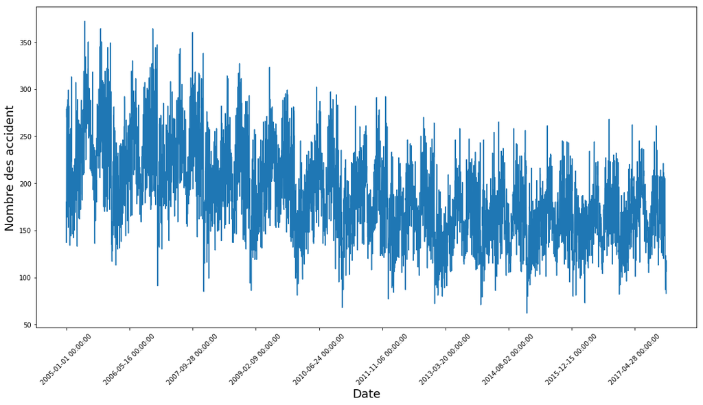

```python
df = df.sort_values('Full_Date')
plt.figure(figsize = (18,9))
plt.plot(range(df.shape[0]),df['Number'])
plt.xticks(range(0,df.shape[0],500),df['Full_Date'].loc[::500],rotation=45)
plt.xlabel('Date',fontsize=18)
plt.ylabel('Nombre des accident',fontsize=18)
plt.show()
```

```python
train_data = df.iloc[:4000,1].values
test_data = df.iloc[4000:,1].values
scaler = MinMaxScaler()
train_data = train_data.reshape(-1,1)
test_data = test_data.reshape(-1,1)
```

il existe des evenements ou leurs dates ne sont pas encore fixés donc il faut les supprimer

```python
events=events.dropna(subset=['Date_début','Date_de_fin'])
```

```python
from datetime import datetime
Start_Full_Date = []
for i in events.Date_début:
    Start_Full_Date.append(datetime.strptime(str(i), '%Y-%m-%d'))
events["Start_Full_Date"] = Start_Full_Date
```

```python
from datetime import datetime
End_Full_Date = []
for i in events.Date_de_fin:
    End_Full_Date.append(datetime.strptime(str(i), '%Y-%m-%d'))
events["End_Full_Date"] = End_Full_Date
```

```python
def missing_data(data):
    total = round(data.isnull().sum().sort_values(ascending = False),2)
    percent = round((data.isnull().sum()/data.isnull().count()*100).sort_values(ascending = False),2)
    return pd.concat([total, percent.astype("str")+" %"], axis=1, keys=['Total NaN Values', 'Percentage of NaN Values'])

missing_data(events)
```

|  | Total NaN Values | Percentage of NaN Values |
| --- | --- | --- |
| share_url | 377940 | 100.0 % |
| Quartier | 347590 | 91.97 % |
| program_uid | 303870 | 80.4 % |
| Mots_clés | 221258 | 58.54 % |
| Tarif | 141518 | 37.44 % |
| Image | 112689 | 29.82 % |
| Vignette | 112689 | 29.82 % |
| Détails | 86205 | 22.81 % |
| Département | 34737 | 9.19 % |
| Région | 32895 | 8.7 % |
| Ville | 26100 | 6.91 % |
| Description | 6509 | 1.72 % |
| Titre | 4538 | 1.2 % |
| Adresse | 68 | 0.02 % |
| Place | 2 | 0.0 % |
| uid | 1 | 0.0 % |
| latlon | 0 | 0.0 % |
| Start_Full_Date | 0 | 0.0 % |
| Date_début | 0 | 0.0 % |
| Langue | 0 | 0.0 % |
| Date_de_fin | 0 | 0.0 % |
| timetable | 0 | 0.0 % |
| Date_mise_à_jour | 0 | 0.0 % |
| Période | 0 | 0.0 % |
| Lien | 0 | 0.0 % |
| End_Full_Date | 0 | 0.0 % |

```python
test = events[(events['Date_début'] > '2019-01-01')]
```

```python
test.shape
```

```
(9122, 26)
```

```python
y=pd.DataFrame()
y['Start_Full_Date']=test['Start_Full_Date']
y['End_Full_Date']=test['End_Full_Date']
y.head()
```

|  | Start_Full_Date | End_Full_Date |
| --- | --- | --- |
| 313 | 2019-01-15 00:00:00 | 2019-01-31 00:00:00 |
| 320 | 2019-03-07 00:00:00 | 2019-03-19 00:00:00 |
| 321 | 2019-05-11 00:00:00 | 2019-05-11 00:00:00 |
| 362 | 2019-04-02 00:00:00 | 2019-04-02 00:00:00 |
| 664 | 2019-06-22 00:00:00 | 2019-06-22 00:00:00 |

```python
number=[]
np.random.seed(7)
import random
Event_to_predict=pd.DataFrame({'Full_Date':y['Start_Full_Date']})

Event_to_predict=Event_to_predict[:500]
for x in range(len(Event_to_predict)):
    number.append(random.randint(1,101))
Event_to_predict[0]=number
Event_to_predict=Event_to_predict.set_index('Full_Date')
Event_to_predict.shape
```

```
(500, 1)
```

```python
yfinale=pd.DataFrame()
yfinale['Start_Full_Date']=Event_to_predict.index
yfinale=yfinale[:498]
yfinale
yfinale['Start_Full_Date'] =  pd.to_datetime(yfinale['Start_Full_Date'])
```

```python
from keras.models import Sequential
from keras.layers import Dense
from keras.layers import LSTM
from sklearn.preprocessing import MinMaxScaler
from sklearn.metrics import mean_squared_error
import numpy as np
```

```python
dff=pd.DataFrame(df1.groupby('Full_Date').size())
dff = dff.values
dff = dff.astype('float32')
scaler = MinMaxScaler(feature_range=(0, 1))
dff = scaler.fit_transform(dff)
```

```python
train_size = int(len(dff) * 0.67)
test_size = len(dff) - train_size
train, test = dff[0:train_size,:], dff[train_size:len(dff),:]
print(len(train), len(test))
```

```
3181 1567
```

```python
def create_dataset(dataset, look_back=1):
    dataX, dataY = [], []
    for i in range(len(dataset)-look_back-1):
        a = dataset[i:(i+look_back), 0]
        dataX.append(a)
        dataY.append(dataset[i + look_back, 0])
    return np.array(dataX), np.array(dataY)
```

```python
look_back = 1
trainX, trainY = create_dataset(train, look_back)
testX, testY = create_dataset(test, look_back)
```

```python
trainX = np.reshape(trainX, (trainX.shape[0], 1, trainX.shape[1]))
testX = np.reshape(testX, (testX.shape[0], 1, testX.shape[1]))
```

```python
model = Sequential()
model.add(LSTM(4, input_shape=(1, look_back)))
model.add(Dense(1))
model.compile(loss='mean_squared_error', optimizer='adam')
model.fit(trainX, trainY, epochs=10, batch_size=1, verbose=2)
```

```
 - 6s - loss: 0.0214
 - 5s - loss: 0.0137
 - 5s - loss: 0.0136
 - 5s - loss: 0.0136
 - 5s - loss: 0.0136
 - 5s - loss: 0.0136
 - 5s - loss: 0.0136
 - 5s - loss: 0.0136
 - 5s - loss: 0.0135
 - 5s - loss: 0.0136
```

```
<keras.callbacks.History at 0x7f08ffef6a90>
```

```python
# make predictions
trainPredict = model.predict(trainX)
testPredict = model.predict(testX)
# invert predictions
trainPredict = scaler.inverse_transform(trainPredict)
trainY = scaler.inverse_transform([trainY])
testPredict = scaler.inverse_transform(testPredict)
testY = scaler.inverse_transform([testY])
# calculate root mean squared error
trainScore = math.sqrt(mean_squared_error(trainY[0], trainPredict[:,0]))
print('Train Score: %.2f RMSE' % (trainScore))
testScore = math.sqrt(mean_squared_error(testY[0], testPredict[:,0]))
print('Test Score: %.2f RMSE' % (testScore))
```

```
Train Score: 35.87 RMSE
Test Score: 31.70 RMSE
```

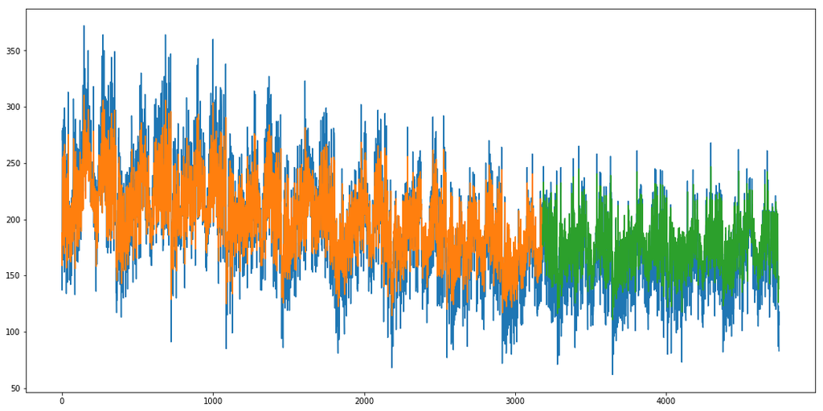

```python
# shift train predictions for plotting
plt.figure(figsize = (18,9))

trainPredictPlot = np.empty_like(dff)
trainPredictPlot[:, :] = np.nan
trainPredictPlot[look_back:len(trainPredict)+look_back, :] = trainPredict
# shift test predictions for plotting
testPredictPlot = np.empty_like(dff)
testPredictPlot[:, :] = np.nan
testPredictPlot[len(trainPredict)+(look_back*2)+1:len(dff)-1, :] = testPredict
# plot baseline and predictions
plt.plot(scaler.inverse_transform(dff))
plt.plot(trainPredictPlot)
plt.plot(testPredictPlot)
plt.show()
```

Maitenant on va prédire le nombre d'accident relié à chaque evenement

```python
dfevents=pd.concat([pd.DataFrame(df1.groupby('Full_Date').size()),Event_to_predict ])
dfevents = dfevents.sort_index()
dfevents.tail
```

[output not shown]

[output cut: 10 more lines]

[output not shown]

```python
dfevents.shape
```

```
(5248, 1)
```

```python
dfevents = dfevents.values
dfevents = dfevents.astype('float32')
scaler = MinMaxScaler(feature_range=(0, 1))
dfevents = scaler.fit_transform(dfevents)
```

```python
train, test = dfevents[0:4748,:], dfevents[4748:,:]
print(len(train), len(test))
```

```
4748 500
```

```python
look_back = 1
trainX, trainY = create_dataset(train, look_back)
testX, testY = create_dataset(test, look_back)
```

```python
trainX = np.reshape(trainX, (trainX.shape[0], 1, trainX.shape[1]))
testX = np.reshape(testX, (testX.shape[0], 1, testX.shape[1]))
```

```python
model = Sequential()
model.add(LSTM(4, input_shape=(1, look_back)))
model.add(Dense(1))
model.compile(loss='mean_squared_error', optimizer='adam')
model.fit(trainX, trainY, epochs=10, batch_size=1, verbose=2)
```

```
 - 9s - loss: 0.0155
 - 7s - loss: 0.0087
 - 7s - loss: 0.0087
 - 7s - loss: 0.0087
 - 7s - loss: 0.0087
 - 7s - loss: 0.0087
 - 7s - loss: 0.0087
 - 7s - loss: 0.0087
 - 7s - loss: 0.0087
 - 7s - loss: 0.0087
```

```
<keras.callbacks.History at 0x7f08546caa20>
```

```python
trainPredict = model.predict(trainX)
testPredict = model.predict(testX)
# invert predictions
trainPredict = scaler.inverse_transform(trainPredict)
trainY = scaler.inverse_transform([trainY])
testPredict = scaler.inverse_transform(testPredict)
testY = scaler.inverse_transform([testY])
# calculate root mean squared error
trainScore = math.sqrt(mean_squared_error(trainY[0], trainPredict[:,0]))
testScore = math.sqrt(mean_squared_error(testY[0], testPredict[:,0]))
```

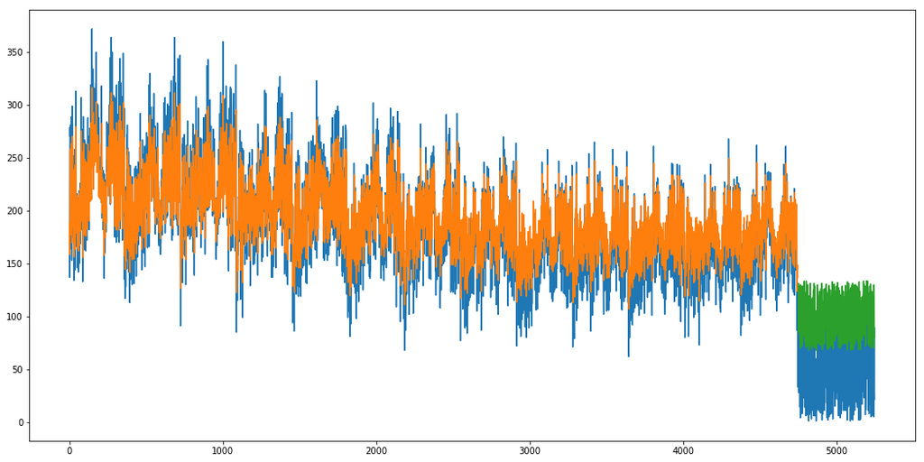

```python
plt.figure(figsize = (18,9))

trainPredictPlot = np.empty_like(dfevents)
trainPredictPlot[:, :] = np.nan
trainPredictPlot[look_back:len(trainPredict)+look_back, :] = trainPredict
# shift test predictions for plotting
testPredictPlot = np.empty_like(dfevents)
testPredictPlot[:, :] = np.nan
testPredictPlot[len(trainPredict)+(look_back*2)+1:len(dfevents)-1, :] = testPredict
plt.plot(scaler.inverse_transform(dfevents))
plt.plot(trainPredictPlot)
plt.plot(testPredictPlot)
plt.show()
```

```python
events=events[:498]
yfinale['Numberofaccidents']=testPredict
yfinale.head()
events.sort_values(by=['Start_Full_Date'])
data2 = yfinale.merge(events[:498], left_on='Start_Full_Date', right_on='Start_Full_Date', how='inner')
```

```python
yfinale.head()
```

|  | Start_Full_Date | Numberofaccidents |
| --- | --- | --- |
| 0 | 2019-01-15 | 87.967628 |
| 1 | 2019-03-07 | 110.273720 |
| 2 | 2019-05-11 | 131.329941 |
| 3 | 2019-04-02 | 95.729858 |
| 4 | 2019-06-22 | 84.772675 |

```python
testPredict.shape
```

```
(498, 1)
```

```python
data2.columns
```

```
Index(['Start_Full_Date', 'End_Full_Date_x', 'Numberofaccidents', 'uid',
       'Lien', 'Période', 'Image', 'Vignette', 'share_url', 'Langue', 'Titre',
       'Description', 'Détails', 'Mots_clés', 'latlon', 'Place', 'Adresse',
       'Département', 'Région', 'Ville', 'Date_début', 'Date_de_fin',
       'timetable', 'Tarif', 'program_uid', 'Date_mise_à_jour', 'Quartier',
       'End_Full_Date_y'],
      dtype='object')
```

```python
data2.columns.drop(['Image', 'Vignette', 'share_url','Date_début', 'Date_de_fin',
       'timetable', 'Tarif', 'program_uid', 'Date_mise_à_jour', 'Quartier',
       'End_Full_Date_y' ])
data2.head()
```

[output not shown]

5 rows × 28 columns

## Indicateur 2 : Nombre des impliqués dans des accidents par jour

Le but de cet indicateur est de prédire le nombres des personnes impliquées dans des accidents **par jour** et **par commune** en se basant sur les situations dans lesquelles ces accidents ont survenus (Conditions météologiques, Lumière, Vacances ou pas, Weekend ou pas ainsi que la période de la journée et le type de route ...)

```python
from sklearn.metrics import mean_squared_error
from math import sqrt
```

Nous allons donc transformer les modalités des variables citées ci-dessus en des colonnes contenant le nombre des accidents ayant cette caractéristiques. Pour cela, nous allons effectuer un **One Hot Encoding** :

```python
def oneHotEncode(df,colNames):
    for col in colNames:
        if( df[col].dtype == np.dtype('object')):
            dummies = pd.get_dummies(df[col],prefix=col)
            df = pd.concat([df,dummies],axis=1)

            #drop the encoded column
            df.drop([col],axis = 1 , inplace=True)
    return df
```

```python
data_blesses = data.copy()
data_blesses["Nb_Blesses"] = 1
```

```python
data2 = data.drop_duplicates(["Num_Accident"]).copy()
cols = [col for col in data.columns if col in ["Agglomeration","Annee","Periode","Mois","Jour","Categorie_Route","Commune","Lumiere","Atmosphere","Num_Accident","Nb_Blesses","Holiday","Weekend"]]
data2.drop(data.columns.difference(cols),axis = 1,inplace = True)
data2 = oneHotEncode(data2,cols)

data2.rename(columns = lambda x: x.replace(" ","_"),inplace=True)
colnames = data2.columns.drop(["Annee","Mois","Jour","Num_Accident","Commune"])
list1 = {}
for x in colnames:
    list1[x] = np.sum
list1["Num_Accident"] = pd.Series.nunique
DataForPrediction = data2.groupby(["Commune","Jour","Mois","Annee"],as_index = False).agg(list1)
DataForPrediction.fillna(0,inplace=True)

data3 = data_blesses.copy()
cols1 = [col for col in data_blesses.columns if col in ["Agglomeration","Annee","Periode","Mois","Jour","Categorie_Route","Commune","Lumiere","Atmosphere","Num_Accident","Nb_Blesses","Holiday","Weekend","Nb_Blesses"]]
data3.drop(data_blesses.columns.difference(cols1),axis = 1,inplace = True)
data3 = oneHotEncode(data3,cols1)

data3.rename(columns = lambda x: x.replace(" ","_"),inplace=True)
colnames2 = data3.columns.drop(["Annee","Mois","Jour","Num_Accident","Commune"])
list2 = {}
for x in colnames2:
    list2[x] = np.sum
list2["Num_Accident"] = pd.Series.nunique
DataForPrediction2 = data3.groupby(["Commune","Jour","Mois","Annee"],as_index = False).agg(list2)
DataForPrediction2.fillna(0,inplace=True)

DataForPrediction["Target"] = DataForPrediction2["Nb_Blesses"]
if("Nb_Blesses" in DataForPrediction.columns):
    DataForPrediction.drop(["Nb_Blesses"],axis=1,inplace=True)
```

### Deep Neural Network

```python
from keras.callbacks import ModelCheckpoint
from keras.models import Sequential
from keras.layers import Dense, Activation, Flatten
from sklearn.model_selection import train_test_split
from sklearn.ensemble import RandomForestRegressor
from sklearn.metrics import mean_absolute_error
from xgboost import XGBRegressor
```

```python
train1 = DataForPrediction.loc[DataForPrediction["Annee"] != 2017,:]
test1 = DataForPrediction.loc[DataForPrediction["Annee"] == 2017,:]
NN_model1 = Sequential()

# The Input Layer :
NN_model1.add(Dense(128, kernel_initializer='normal',input_dim = train1.drop(["Annee","Target"],axis=1).shape[1], activation='relu'))

# The Hidden Layers :
NN_model1.add(Dense(256, kernel_initializer='normal',activation='relu'))
NN_model1.add(Dense(256, kernel_initializer='normal',activation='relu'))
NN_model1.add(Dense(256, kernel_initializer='normal',activation='relu'))

# The Output Layer :
NN_model1.add(Dense(1, kernel_initializer='normal',activation='linear'))

# Compile the network :
NN_model1.compile(loss='mean_absolute_error', optimizer='adam', metrics=['mean_absolute_error'])
#NN_model.summary()

checkpoint_name = 'Weights-{epoch:03d}--{val_loss:.5f}.hdf5'
checkpoint = ModelCheckpoint(checkpoint_name, monitor='val_loss', verbose = 1, save_best_only = True, mode ='auto')
callbacks_list = [checkpoint]

NN_model1.fit(train1.drop(["Annee","Target"],axis=1), train1.Target, epochs=10, batch_size=32, validation_split = 0.2, callbacks=callbacks_list)
```

```
Train on 464386 samples, validate on 116097 samples

Epoch 00001: val_loss improved from inf to 2.48617, saving model to Weights-001--2.48617.hdf5

Epoch 00002: val_loss did not improve from 2.48617

Epoch 00003: val_loss did not improve from 2.48617

Epoch 00004: val_loss did not improve from 2.48617

Epoch 00005: val_loss did not improve from 2.48617

Epoch 00006: val_loss improved from 2.48617 to 2.44050, saving model to Weights-006--2.44050.hdf5

Epoch 00007: val_loss did not improve from 2.44050

Epoch 00008: val_loss improved from 2.44050 to 2.43859, saving model to Weights-008--2.43859.hdf5

Epoch 00009: val_loss did not improve from 2.43859

Epoch 00010: val_loss did not improve from 2.43859
```

```
<keras.callbacks.History at 0x112b64550>
```

```python
wights_file1 = 'Weights-008--2.43859.hdf5'
NN_model1.load_weights(wights_file1) # load it
NN_model1.compile(loss='mean_absolute_error', optimizer='adam', metrics=['mean_absolute_error'])
```

```python
if("Target" in test1.columns):
    y_true = test1.Target
    test1 = test1.drop(['Target'],axis = 1)
if("predictions" in test1.columns):
    test1 = test1.drop(['predictions'],axis = 1)
if("Annee" in test1.columns):
    test1 = test1.drop(['Annee'],axis = 1)
predictions = NN_model1.predict(test1)
test1["Target"] = y_true
test1["predictions"] = predictions
print(sqrt(mean_squared_error(test1.predictions,test1.Target)))
```

```
5.832043485114026
```

```python
test1.head(20)
```

|  | Commune | Jour | Mois | Lumiere_Crépuscule_ou_aube | Lumiere_Nuit_avec_éclairage_public_allumé | Lumiere_Nuit_avec_éclairage_public_non_allumé | Lumiere_Nuit_sans_éclairage_public | Lumiere_Plein_jour | Agglomeration_En_agglomération | Agglomeration_Hors_agglomération | ... | Holiday_Victoire_des_alliés | Periode_Aube | Periode_Coucher_de_soleil | Periode_Jour | Periode_Nuit | Weekend_weekend | Weekend_workday | Num_Accident | Target | predictions |
| --- | --- | --- | --- | --- | --- | --- | --- | --- | --- | --- | --- | --- | --- | --- | --- | --- | --- | --- | --- | --- | --- |
| 17 | 1 | 1 | 2 | 0 | 0 | 0 | 0 | 1 | 1 | 0 | ... | 0 | 0 | 0 | 1 | 0 | 0 | 1 | 1 | 2 | 3.971410 |
| 25 | 1 | 1 | 3 | 1 | 1 | 0 | 0 | 2 | 2 | 2 | ... | 0 | 0 | 2 | 1 | 1 | 0 | 4 | 4 | 14 | 17.499365 |
| 38 | 1 | 1 | 4 | 0 | 0 | 0 | 0 | 1 | 0 | 1 | ... | 0 | 0 | 1 | 0 | 0 | 1 | 0 | 1 | 1 | 4.040142 |
| 46 | 1 | 1 | 5 | 0 | 0 | 0 | 0 | 2 | 2 | 0 | ... | 0 | 0 | 2 | 0 | 0 | 0 | 2 | 2 | 7 | 6.853745 |
| 64 | 1 | 1 | 7 | 0 | 0 | 0 | 0 | 1 | 0 | 1 | ... | 0 | 0 | 0 | 1 | 0 | 1 | 0 | 1 | 10 | 4.117250 |
| 102 | 1 | 1 | 11 | 0 | 0 | 0 | 0 | 1 | 1 | 0 | ... | 0 | 0 | 0 | 1 | 0 | 0 | 1 | 1 | 2 | 4.150680 |
| 113 | 1 | 1 | 12 | 0 | 1 | 1 | 0 | 1 | 2 | 1 | ... | 0 | 0 | 0 | 1 | 2 | 0 | 3 | 3 | 13 | 13.001446 |
| 130 | 1 | 2 | 2 | 1 | 0 | 0 | 0 | 0 | 1 | 0 | ... | 0 | 0 | 0 | 1 | 0 | 0 | 1 | 1 | 9 | 4.030222 |
| 139 | 1 | 2 | 3 | 0 | 2 | 0 | 0 | 1 | 3 | 0 | ... | 0 | 1 | 0 | 1 | 1 | 0 | 3 | 3 | 10 | 10.079255 |
| 146 | 1 | 2 | 4 | 0 | 0 | 0 | 0 | 1 | 1 | 0 | ... | 0 | 0 | 0 | 0 | 1 | 1 | 0 | 1 | 6 | 4.098308 |
| 164 | 1 | 2 | 6 | 0 | 0 | 0 | 0 | 2 | 1 | 1 | ... | 0 | 0 | 0 | 2 | 0 | 0 | 2 | 2 | 25 | 7.866316 |
| 217 | 1 | 2 | 12 | 0 | 1 | 0 | 2 | 1 | 1 | 3 | ... | 0 | 0 | 2 | 1 | 1 | 4 | 0 | 4 | 7 | 16.354338 |
| 224 | 1 | 3 | 1 | 0 | 0 | 0 | 0 | 2 | 2 | 0 | ... | 0 | 0 | 0 | 2 | 0 | 0 | 2 | 2 | 18 | 7.275402 |
| 232 | 1 | 3 | 2 | 1 | 1 | 0 | 2 | 0 | 2 | 2 | ... | 0 | 0 | 0 | 2 | 2 | 0 | 4 | 4 | 26 | 16.306459 |
| 242 | 1 | 3 | 3 | 0 | 1 | 0 | 0 | 1 | 1 | 1 | ... | 0 | 0 | 0 | 1 | 1 | 0 | 2 | 2 | 6 | 8.122500 |
| 285 | 1 | 3 | 7 | 0 | 1 | 0 | 0 | 0 | 1 | 0 | ... | 0 | 1 | 0 | 0 | 0 | 0 | 1 | 1 | 6 | 2.929681 |
| 297 | 1 | 3 | 8 | 0 | 0 | 0 | 0 | 1 | 0 | 1 | ... | 0 | 0 | 0 | 1 | 0 | 0 | 1 | 1 | 4 | 3.988202 |
| 306 | 1 | 3 | 9 | 0 | 0 | 0 | 0 | 1 | 0 | 1 | ... | 0 | 0 | 1 | 0 | 0 | 1 | 0 | 1 | 1 | 4.094255 |
| 317 | 1 | 3 | 10 | 0 | 0 | 0 | 0 | 1 | 1 | 0 | ... | 0 | 0 | 0 | 1 | 0 | 0 | 1 | 1 | 4 | 4.047388 |
| 325 | 1 | 3 | 11 | 0 | 0 | 0 | 0 | 2 | 2 | 0 | ... | 0 | 0 | 0 | 2 | 0 | 0 | 2 | 2 | 8 | 8.256330 |

20 rows × 47 columns

### Prédiction du nombre de piétons bléssés par commune en 2017:

```python
data2=data.loc[data["Annee"] == 2017,].copy()
```

```python
data2=oneHotEncode(data2,["Lumiere","Agglomeration","Intersection","Atmosphere","Type_Collision","GPS","Categorie_Usager","Gravite","Sexe_Usager","Trajet","Action_Pieton","Categorie_Vehicule","Obstacle_Mobile_Heurte","Pt_Choc_initiale","Manoeuvre","Categorie_Route","Regime_Circulation","Voie_Reservee","Situation_Accident"])
```

```python
data2.columns = [c.replace(' ', '_') for c in data2.columns]
```

```python
data2['target'] = np.where(
    np.logical_and(
        np.logical_or(data2.Gravite_Blessé_hospitalisé_==1,data2.Gravite_Blessé_léger==1)
                  ,
        np.logical_or(data2["Categorie_Usager_Piéton"]==1,data2["Categorie_Usager_Piéton_en_roller_ou_en_trottinette"]==1)
                  )
    , 1, 0)
```

```python
DataForPrediction = data2.groupby(["Commune"],as_index=False).agg(np.sum)
```

```python
X = DataForPrediction.loc[:, "Lumiere_Crépuscule_ou_aube":"Situation_Accident_Sur_trottoir"].values
y = DataForPrediction.iloc[:, -1].values
from sklearn.cross_validation import train_test_split
X_train, X_test, y_train, y_test = train_test_split(X, y, test_size = 0.31, random_state = 0)
X_train= X_train.astype(int)
```

```python
from sklearn.ensemble import RandomForestRegressor
rf = RandomForestRegressor(n_estimators=100, oob_score=True, random_state=0)
rf.fit(X_train, y_train)
predictions=rf.predict(X_test)
```

```python
import sklearn.metrics as metrics
from math import sqrt
print((metrics.mean_squared_error(predictions, y_test)))
```

```
4.598794047619046
```

## Web Scraping - Segmentation

```python
import requests
from bs4 import BeautifulSoup

URL = "https://fr.wikipedia.org/wiki/Accident_de_la_route_en_Europe"

Pays=[]

Superficie=[]

Population=[]

Densité=[]

Parc_en_circulation=[]

Longueur_du_réseau=[]

Circulation=[]

Nb_de_véhic=[]

Tués=[]

Tués2=[]
res = requests.get(URL).text
soup = BeautifulSoup(res,'lxml')
for items in soup.find('table', class_='wikitable').find_all('tr')[1::1]:
    data = items.find_all(['th','td'])
    try:
        Pays.append(data[0].a.text)
        Superficie.append(data[1].text)
        Population.append(data[2].text)
        Densité.append(data[3].text)
        Parc_en_circulation.append(data[4].text)
        Longueur_du_réseau.append(data[5].text)
        Circulation.append(data[6].text)
        Nb_de_véhic.append(data[7].text)
        Tués.append(data[8].text)
        Tués2.append(data[9].text)

    except IndexError:pass
```

[output not shown]

```python
data=[Superficie,Population,Densité,Parc_en_circulation,Longueur_du_réseau,Circulation,Nb_de_véhic,Tués,Tués2]
import unidecode
for item in data:
    for i in range(len(item)):
        item[i] = unidecode.unidecode(item[i])
        item[i] = item[i].replace(' ', '')
        item[i] = item[i].replace('\n', '')
        item[i] = item[i].replace('ND', 'NaN')
        item[i] = item[i].replace(',', '.')
```

```python
df= pd.DataFrame(columns=Pays,data=data)
```

```python
df1=df.T
```

```python
df1.columns=["Superficie(milliers de km²)","Population(millions)","Densité(habitants/km2)"
             ,"Parc en circulation (milliers)","Longueur du réseau (kilomètres)","Circulation (millions de véhicules x km)"
             ,"Nb de véhic pour 100 habitants","Tués par million d'habitants","Tués par milliard de km parcourus"]
```

```python
df1
```

|  | Superficie(milliers de km²) | Population(millions) | Densité(habitants/km2) | Parc en circulation (milliers) | Longueur du réseau (kilomètres) | Circulation (millions de véhicules x km) | Nb de véhic pour 100 habitants | Tués par million d'habitants | Tués par milliard de km parcourus |
| --- | --- | --- | --- | --- | --- | --- | --- | --- | --- |
| Allemagne | 357 | 80.6 | 225.7 | 54520 | 626981 | 684283 | 66.1 | 64.8 | 7.8 |
| Autriche | 84 | 8.4 | 100 | 5279 | 107143 | 82221 | 64.5 | 93.8 | 9.3 |
| Belgique | 33 | 11.1 | 336.4 | 6159 | 151372 | 94677 | 59.1 | 104.5 | 11.5 |
| Danemark | 43 | 5.4 | 125.6 | 2570 | 72074 | 47940 | 47.3 | 61 | 6.9 |
| Espagne | 505 | 47.3 | 93 | 27657 | 666204 | NaN | 63.7 | 103.1 | NaN |
| Finlande | 338 | 5.4 | 16 | 2871 | 79150 | 51675 | 54.7 | 72.2 | 7.3 |
| France | 551 | 66.6 | 120.9 | 37168 | 1002486 | 552800 | 61.4 | 87.9 | 9.6 |
| Grèce | 132 | 10.8 | 81.8 | 6641 | 40164 | 81635 | 59.9 | 149.1 | 20.3 |
| Hongrie | 93 | 9.9 | 106.4 | 3370 | 180994 | NaN | 33.4 | 126.6 | NaN |
| Irlande | 71 | 4.5 | 63.3 | 1937 | 95752 | 37840 | 46.7 | 96.2 | 10.5 |
| Italie | 301 | 60.9 | 202.3 | 43141 | 305388 | 654197 | 74.3 | 94 | 8.3 |
| Luxembourg | 3 | 0.5 | 166.7 | 358 | 2876 | 2875 | 77 | 98.9 | 16 |
| Pays-Bas | 42 | 16.8 | 400 | 8627 | 117430 | 133800 | 52.9 | 46 | 5.6 |
| Pologne | 323 | 38.5 | 119.2 | 16815 | 381462 | 377289 | 43.6 | 141.3 | 14.4 |
| Portugal | 93 | 10.5 | 112.9 | 5481 | 81739 | NaN | 52.2 | 118.8 | NaN |
| Royaume-Uni | 244 | 63.2 | 259 | 33717 | 413120 | 499396 | 56 | 55.9 | 6.7 |
| Slovaquie | 49 | 5.4 | 110.2 | 1834 | 17755 | 13402 | 34 | 112.6 | 45.4 |
| Slovénie | 20 | 2 | 100 | 1150 | 20196 | 15519 | 58.5 | 131.2 | 16.6 |
| Suède | 450 | 9.5 | 21.1 | 5131 | 214000 | 75196 | 56.8 | 48.7 | 5.9 |
| République tchèque | 79 | 10.5 | 132.9 | 4732 | 55495 | 50262 | 46.3 | 125.8 | 27.2 |

```python
df2 = df1.apply(pd.to_numeric, errors = 'coerce')
```

```python
df2
```

|  | Superficie(milliers de km²) | Population(millions) | Densité(habitants/km2) | Parc en circulation (milliers) | Longueur du réseau (kilomètres) | Circulation (millions de véhicules x km) | Nb de véhic pour 100 habitants | Tués par million d'habitants | Tués par milliard de km parcourus |
| --- | --- | --- | --- | --- | --- | --- | --- | --- | --- |
| Allemagne | 357 | 80.6 | 225.7 | 54520 | 626981 | 684283.0 | 66.1 | 64.8 | 7.8 |
| Autriche | 84 | 8.4 | 100.0 | 5279 | 107143 | 82221.0 | 64.5 | 93.8 | 9.3 |
| Belgique | 33 | 11.1 | 336.4 | 6159 | 151372 | 94677.0 | 59.1 | 104.5 | 11.5 |
| Danemark | 43 | 5.4 | 125.6 | 2570 | 72074 | 47940.0 | 47.3 | 61.0 | 6.9 |
| Espagne | 505 | 47.3 | 93.0 | 27657 | 666204 | NaN | 63.7 | 103.1 | NaN |
| Finlande | 338 | 5.4 | 16.0 | 2871 | 79150 | 51675.0 | 54.7 | 72.2 | 7.3 |
| France | 551 | 66.6 | 120.9 | 37168 | 1002486 | 552800.0 | 61.4 | 87.9 | 9.6 |
| Grèce | 132 | 10.8 | 81.8 | 6641 | 40164 | 81635.0 | 59.9 | 149.1 | 20.3 |
| Hongrie | 93 | 9.9 | 106.4 | 3370 | 180994 | NaN | 33.4 | 126.6 | NaN |
| Irlande | 71 | 4.5 | 63.3 | 1937 | 95752 | 37840.0 | 46.7 | 96.2 | 10.5 |
| Italie | 301 | 60.9 | 202.3 | 43141 | 305388 | 654197.0 | 74.3 | 94.0 | 8.3 |
| Luxembourg | 3 | 0.5 | 166.7 | 358 | 2876 | 2875.0 | 77.0 | 98.9 | 16.0 |
| Pays-Bas | 42 | 16.8 | 400.0 | 8627 | 117430 | 133800.0 | 52.9 | 46.0 | 5.6 |
| Pologne | 323 | 38.5 | 119.2 | 16815 | 381462 | 377289.0 | 43.6 | 141.3 | 14.4 |
| Portugal | 93 | 10.5 | 112.9 | 5481 | 81739 | NaN | 52.2 | 118.8 | NaN |
| Royaume-Uni | 244 | 63.2 | 259.0 | 33717 | 413120 | 499396.0 | 56.0 | 55.9 | 6.7 |
| Slovaquie | 49 | 5.4 | 110.2 | 1834 | 17755 | 13402.0 | 34.0 | 112.6 | 45.4 |
| Slovénie | 20 | 2.0 | 100.0 | 1150 | 20196 | 15519.0 | 58.5 | 131.2 | 16.6 |
| Suède | 450 | 9.5 | 21.1 | 5131 | 214000 | 75196.0 | 56.8 | 48.7 | 5.9 |
| République tchèque | 79 | 10.5 | 132.9 | 4732 | 55495 | 50262.0 | 46.3 | 125.8 | 27.2 |

```python
from sklearn.preprocessing import Imputer
imputer = Imputer(missing_values = 'NaN', strategy = 'median', axis = 0)
imputer.fit(df2.iloc[:, [5,8]])
df2.iloc[:, [5,8]] = imputer.transform(df2.iloc[:, [5,8]])
```

```python
X=df2.values
from sklearn.preprocessing import StandardScaler
sc = StandardScaler()
X = sc.fit_transform(X)
```

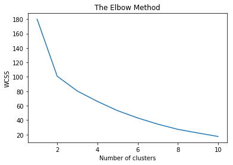

```python
import matplotlib.pyplot as plt
from sklearn.cluster import KMeans
%matplotlib inline
wcss = []
for i in range(1, 11):
    kmeans = KMeans(n_clusters = i, init = 'k-means++', random_state = 42)
    kmeans.fit(X)
    wcss.append(kmeans.inertia_)
plt.plot(range(1, 11), wcss)
plt.title('The Elbow Method')
plt.xlabel('Number of clusters')
plt.ylabel('WCSS')
plt.show()
```

```python
kmeans = KMeans(n_clusters = 3, init = 'k-means++', random_state = 2)
y_kmeans = kmeans.fit_predict(X)
```

```python
from sklearn.decomposition import PCA
pca = PCA(n_components=2).fit(X)
pca_2d = pca.transform(X)
```

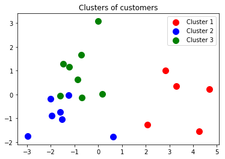

```python
# Visualising the clusters
plt.scatter(pca_2d[y_kmeans == 0, 0], pca_2d[y_kmeans == 0, 1], s = 100, c = 'red', label = 'Cluster 1')
plt.scatter(pca_2d[y_kmeans == 1, 0], pca_2d[y_kmeans == 1, 1], s = 100, c = 'blue', label = 'Cluster 2')
plt.scatter(pca_2d[y_kmeans == 2, 0], pca_2d[y_kmeans == 2, 1], s = 100, c = 'green', label = 'Cluster 3')
plt.title('Clusters of customers')
plt.legend()
plt.show()
```

```python
df2["Cluster"]=y_kmeans
```

```python
df2
```

|  | Superficie(milliers de km²) | Population(millions) | Densité(habitants/km2) | Parc en circulation (milliers) | Longueur du réseau (kilomètres) | Circulation (millions de véhicules x km) | Nb de véhic pour 100 habitants | Tués par million d'habitants | Tués par milliard de km parcourus | Cluster |
| --- | --- | --- | --- | --- | --- | --- | --- | --- | --- | --- |
| Allemagne | 357 | 80.6 | 225.7 | 54520 | 626981 | 684283.0 | 66.1 | 64.8 | 7.8 | 0 |
| Autriche | 84 | 8.4 | 100.0 | 5279 | 107143 | 82221.0 | 64.5 | 93.8 | 9.3 | 2 |
| Belgique | 33 | 11.1 | 336.4 | 6159 | 151372 | 94677.0 | 59.1 | 104.5 | 11.5 | 2 |
| Danemark | 43 | 5.4 | 125.6 | 2570 | 72074 | 47940.0 | 47.3 | 61.0 | 6.9 | 2 |
| Espagne | 505 | 47.3 | 93.0 | 27657 | 666204 | 81635.0 | 63.7 | 103.1 | 9.6 | 0 |
| Finlande | 338 | 5.4 | 16.0 | 2871 | 79150 | 51675.0 | 54.7 | 72.2 | 7.3 | 2 |
| France | 551 | 66.6 | 120.9 | 37168 | 1002486 | 552800.0 | 61.4 | 87.9 | 9.6 | 0 |
| Grèce | 132 | 10.8 | 81.8 | 6641 | 40164 | 81635.0 | 59.9 | 149.1 | 20.3 | 1 |
| Hongrie | 93 | 9.9 | 106.4 | 3370 | 180994 | 81635.0 | 33.4 | 126.6 | 9.6 | 1 |
| Irlande | 71 | 4.5 | 63.3 | 1937 | 95752 | 37840.0 | 46.7 | 96.2 | 10.5 | 2 |
| Italie | 301 | 60.9 | 202.3 | 43141 | 305388 | 654197.0 | 74.3 | 94.0 | 8.3 | 0 |
| Luxembourg | 3 | 0.5 | 166.7 | 358 | 2876 | 2875.0 | 77.0 | 98.9 | 16.0 | 2 |
| Pays-Bas | 42 | 16.8 | 400.0 | 8627 | 117430 | 133800.0 | 52.9 | 46.0 | 5.6 | 2 |
| Pologne | 323 | 38.5 | 119.2 | 16815 | 381462 | 377289.0 | 43.6 | 141.3 | 14.4 | 1 |
| Portugal | 93 | 10.5 | 112.9 | 5481 | 81739 | 81635.0 | 52.2 | 118.8 | 9.6 | 1 |
| Royaume-Uni | 244 | 63.2 | 259.0 | 33717 | 413120 | 499396.0 | 56.0 | 55.9 | 6.7 | 0 |
| Slovaquie | 49 | 5.4 | 110.2 | 1834 | 17755 | 13402.0 | 34.0 | 112.6 | 45.4 | 1 |
| Slovénie | 20 | 2.0 | 100.0 | 1150 | 20196 | 15519.0 | 58.5 | 131.2 | 16.6 | 1 |
| Suède | 450 | 9.5 | 21.1 | 5131 | 214000 | 75196.0 | 56.8 | 48.7 | 5.9 | 2 |
| République tchèque | 79 | 10.5 | 132.9 | 4732 | 55495 | 50262.0 | 46.3 | 125.8 | 27.2 | 1 |

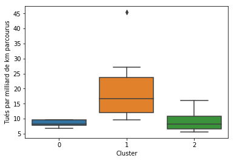

```python
import seaborn as sns

p1=sns.boxplot(x='Cluster', y='Tués par milliard de km parcourus', data=df2, order=[0,1,2])
```

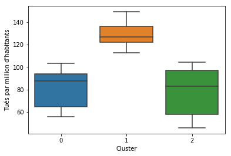

```python
p2=sns.boxplot(x='Cluster', y="Tués par million d'habitants", data=df2, order=[0,1,2])
```